# Workshop Luxembourg Phenotypic Axes

Cynthia Sandor

Last update: Thu Jan 31 14:32:01 2019

## Using PHENIX

### Introduction

PHENIX (Dahl et al., 2016) use a Bayesian multiple-phenotype mixed model (MPMM), where the correlations between clinical phenotypes (Y) are decomposed into a genetic and a residual component with the following model: Y=U+e, where U represents the aggregate genetic contribution (whole genotype) to phenotypic variance and e is idiosyncratic noise.

As the estimation of maximum likelihood covariance estimates can become computationally expensive with increasing number of phenotypes, PHENIX uses a Bayesian low-rank matrix factorization model for the genetic term U such as: U = Sβ, in which β is can be used to estimate the genetic covariance matrix between phenotypes and S represents a matrix of latent components that each follow ~N (0,G) where G is the Estimate of Relatedness Matrix from genotypes.

The resulting latent traits (S) are used as phenotypic axes, each representing the severity of a number of non-independent clinical phenotypes.

To run PHENIX, we need: (1) Phenotypic matrix (P) (2) Kinship Matrix calculted from genotype from individual.

### Phenotypic matrix

The PPMI cohort (http://www.ppmi-info.org) was already described in detail (including PPMI protocol of recruitment and informed consent) by Marrek et al. (Parkinson Progression Marker, 2011).

We downloaded data from the PPMI database on September 2017 in compliance with the PPMI Data Use Agreement. We considered 472 newly-diagnosed typical Parkinson’s disease subjects: subjects with a diagnosis of Parkinson’s disease for two years or less and who are not taking Parkinson’s disease medications.

We used the baseline (t=0) of clinical assessments, described in detail in the Supplementary Table 2. We excluded any individual with > 5% of missing data (441 individuals included).

We used the baseline following clinical assessement

```r
index_phen<-def_phen$Variable.Name %in% colnames(Y)
df<-def_phen[index_phen,]
DT::datatable(df, rownames = TRUE, caption = "Clinical Assessements", escape = FALSE, extensions = 'Buttons', options = list(dom = 'ftipr'))
```

|  | Variable.Name | Category | Variable.description |
| --- | --- | --- | --- |
| 1 | UPDRS_apathy | Anxiety_Depression | MDS UPDRS part I apathy question rated 0-4. A higher score corresponds with greater apathy. |
| 2 | UPDRS_hallucinations | Anxiety_Depression | MDS UPDRS part I hallucination question rated 0-4. A higher score corresponds with more hallucinations. |
| 3 | QUIP_all | Anxiety_Depression | Questionnaire for Impulsive-Compulsive Disorder |
| 4 | Geriatic_Depression_Total | Anxiety_Depression | Geriatric Depression Scale (GDS-15) |
| 5 | SCOPA_urinary | Autonomic | SCOPA-AUT. A questionnaire to assess autonomic symptoms in patients with Parkinsons disease |
| 6 | SCOPA_cardiovascular | Autonomic | SCOPA-AUT. A questionnaire to assess autonomic symptoms in patients with Parkinsons disease |
| 7 | SCOPA_pupillomotor | Autonomic | SCOPA-AUT. A questionnaire to assess autonomic symptoms in patients with Parkinsons disease |
| 8 | SCOPA_gastro | Autonomic | SCOPA-AUT. A questionnaire to assess autonomic symptoms in patients with Parkinsons disease |
| 9 | MOCA_total | Cognitive | Montreal Cognitive Assessment. A battery of different questions measuring cognitive ability. A higher score corresponds with better cognition. |
| 10 | education_years | Cognitive | Number of years of education |

[output cut: 23 more lines]

### Kindship matrix

The kinship matrix G that is used by PHENIX to identify who’s related to each other, was created by using the GEMMA software (version 0.95) (Zhou and Stephens, 2012; Zhou et al., 2013; Zhou and Stephens, 2014) from genotype file under plink binary format. We pruned out SNPs in LD by using the following plink commands:

```
./plink - - bfile *plink binary files* - - indep-pairwise 50 5 0.2 - - out *output filename 1*
./plink - - bfile *plink binary files* - - exclude *output filename 1* - - make-bed - - out *output filename 2*
```

We then ran GEMMA with the following command:

```
./gemma -bfile *plink binary files of Parkinson’s disease cases with pruned SNPs* -gk 2 -o *output filename*
```

### Running PHENIX

We have two matrices of dimensions

```r
print ("Dimension of the phenotypic matrix (nxp)")
```

```
## [1] "Dimension of the phenotypic matrix (nxp)"
```

```r
dim(Y)
```

```
## [1] 441  33
```

```r
print ("Dimension of the Kinship matrix (nxn)")
```

```
## [1] "Dimension of the Kinship matrix (nxn)"
```

```r
dim(K)
```

```
## [1] 441 441
```

Running PHENIX The options quantnorm, scale and trim are important because they concern how PHENIX treats the data before generating the components:

Quantile normalizes phenotypes prior to imputation. While trim indicate to remove the outlier

```r
out_phenix<-phenix (Y, K, quantnorm=TRUE, scale=TRUE, trim=FALSE)
```

```
## [1] "range:"                "-6.15783938633509e-12" "-6.15783938633509e-12"
## [1] "number:" "1"
## [1] "Setting negative eigenvalues to 0"
```

The latent variables that correspond to phenotypic axes are saved in phenix_object$S. The dimension of this matrix is the same than phenotypic matrix.

```r
print("Dimension of latent variables matrix (phenotypic axes)")
```

```
## [1] "Dimension of latent variables matrix (phenotypic axes)"
```

```r
S<-out_phenix$S
print(dim(S))
```

```
## [1] 441  33
```

## Phenotypic axis proprieties

### Fraction of the clinical variation

All axes don’t explain the same proportion of the phenotypic variation.

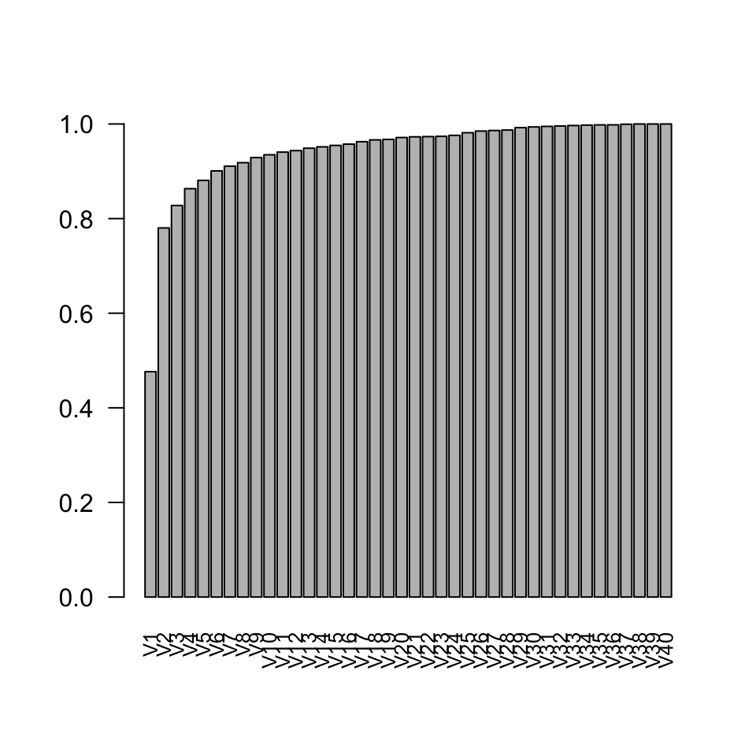

```r
sd_beta<-apply(out$beta[,c(1:33)], 1, sd)
var_expl<-cumsum((sd_beta)^2) / sum(sd_beta^2)
barplot(var_expl[1:length(sd_beta)],names.arg=paste0("V",c(1:length(sd_beta))),las=2,cex.names = 0.8)
```

```r
print ("3 first axes explain")
```

```
## [1] "3 first axes explain"
```

```r
print(var_expl[3])
```

```
## [1] 0.8276959
```

### First phenotypic axes are robust in term of clinical variables considered

```r
n_miss<-5
n_phen<-dim(Y)[2]
set.seed(123458)
list_random_phen<-sample(c(1:n_phen),5)
print("We remove the following clinical features")
```

```
## [1] "We remove the following clinical features"
```

```r
print(colnames(Y)[list_random_phen])
```

```
## [1] "UPDRS_I"                   "UPDRS_tremor"
## [3] "Geriatic_Depression_Total" "SCOPA_gastro"
## [5] "HOPKINKS_DVT_TOTAL_RECALL"
```

```r
Y_miss<-Y[,-list_random_phen]
print("New phenotypic matrix has as dimension")
```

```
## [1] "New phenotypic matrix has as dimension"
```

```r
dim(Y_miss)
```

```
## [1] 441  28
```

```r
print("Running PHENIX with this new matrix")
```

```
## [1] "Running PHENIX with this new matrix"
```

```r
out_phenix_miss<-phenix (Y_miss, K, seed=8473, quantnorm=TRUE, scale=TRUE, trim=FALSE)
```

```
## [1] "range:"                "-6.15783938633509e-12" "-6.15783938633509e-12"
## [1] "number:" "1"
## [1] "Setting negative eigenvalues to 0"
```

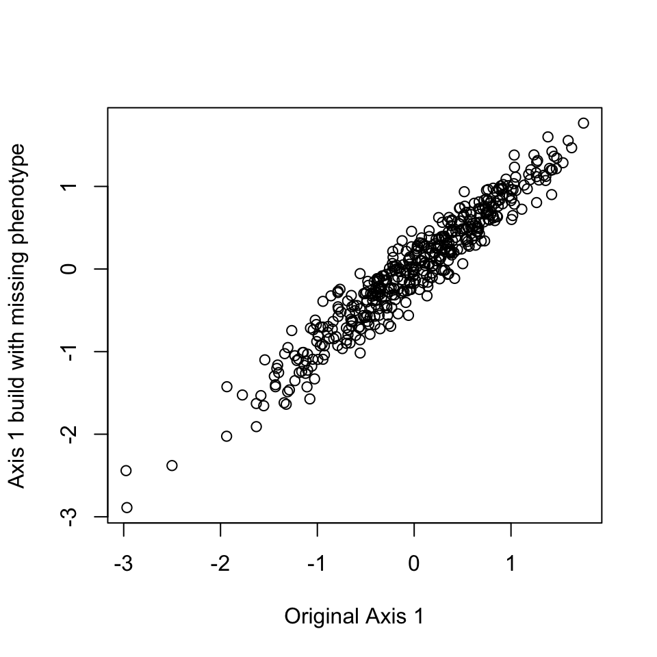

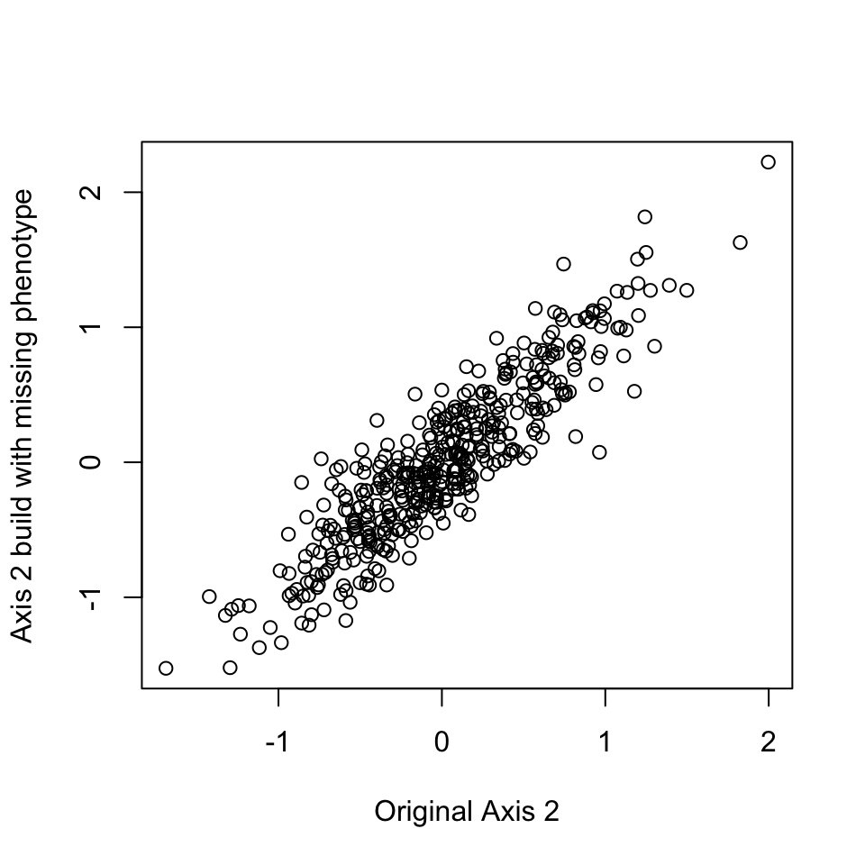

### Each phenotypic axis represents a distinct set of clinical features

To interpret the clinical relevance of each phenotypic axis, we examined the correlation between individual clinical features and the phenotypic axes. To interpret these correlations it is important to know for each individuals clinical feature if a high score is associated with worsening symptoms or not. For example a high score for UPDRS III correspond to worsening motors symptoms, while a high score for MoCA test reflect a better cognitive function for the patient. In consequence the interpretation of positive or negative correlation will depend on the clinical feature.

```r
n_clinical<-length(colnames(Y))
n_axes<-2
list_axes<-c(1,2)
mm <- matrix(NA,n_clinical,n_axes)
for (i in 1:n_axes) {
  for (j in 1:n_clinical) {
    t<-cor.test(Y[,j],out_phenix[["S"]][,i])
    mm[j,i]<-as.numeric(round(t$estimate,3))
  }
}
df_mm<-as.data.frame(mm)
df_mm$Variable.Name<-colnames(Y)
df_mm_info<-merge(df_mm,def_phen,by=c("Variable.Name"))

df_mm_info<-df_mm_info[,c(1,4,2,3)]
colnames(df_mm_info)[1]<-"Clinical_Obs"
DT::datatable(df_mm_info, rownames = TRUE, caption = "Correlation Phenotypic Axes with Clinical Features", escape = FALSE, extensions = 'Buttons', options = list(dom = 'ftipr'))
```

|  | Clinical_Obs | Category | V1 | V2 |
| --- | --- | --- | --- | --- |
| 1 | Anxiety | Anxiety_Depression | 0.066 | -0.13 |
| 2 | Benton_derived_MOANS | Cognitive | 0.415 | -0.068 |
| 3 | education_years | Cognitive | 0.133 | -0.325 |
| 4 | ESS_total | Sleep | -0.202 | 0.326 |
| 5 | Geriatic_Depression_Total | Anxiety_Depression | -0.139 | 0.282 |
| 6 | HOPKINKS_DVT_DELAYED_RECALL | Cognitive | 0.209 | -0.205 |
| 7 | HOPKINKS_DVT_RECOG_DISC_INDEX | Cognitive | 0.068 | 0.136 |
| 8 | HOPKINKS_DVT_RETENTION | Cognitive | 0.108 | -0.138 |
| 9 | HOPKINKS_DVT_TOTAL_RECALL | Cognitive | 0.212 | -0.174 |
| 10 | letter_seq_DVS_LNS | Cognitive | 0.368 | -0.217 |

[output cut: 23 more lines]

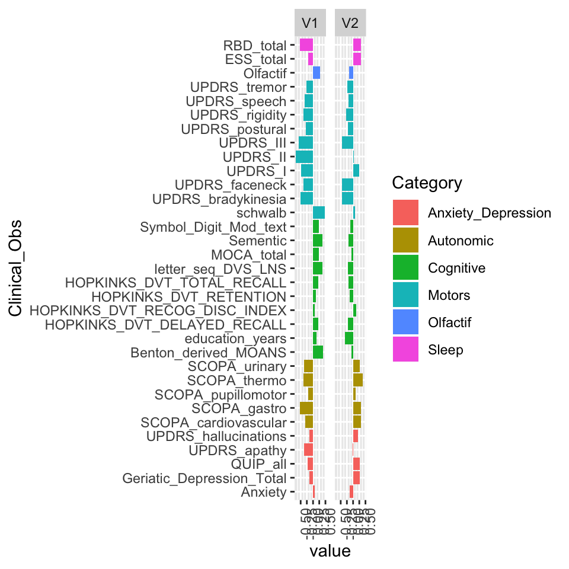

```r
library("reshape2")
library(ggplot2)
df_mm_info_s<-melt(df_mm_info,id=c("Clinical_Obs","Category"))
colnames(df_mm_info_s)[3]<-"Axis"
df_mm_info_s$Clinical_Obs<- factor(df_mm_info_s$Clinical_Obs, levels=unique(df_mm_info_s$Clinical_Obs[order(df_mm_info_s$Category)]))
ggplot(df_mm_info_s, aes(x=Clinical_Obs, y=value,fill=Category))+facet_grid(~Axis)+
 geom_bar(stat='identity',position=position_dodge()) + geom_bar(stat='identity',position=position_dodge()) +  theme(axis.text.x = element_text(angle = 90, hjust = 1))+coord_flip()
```

## Applications

Phenotypic axes are quantive measure of the clinical variation and can be use to explore the genetic underlying the clinical variation or identify new biomarkers such as Cerebrospinal fluid. They measured for 120 individuals:

- Total tau
- Phosphorylated tau
- Amyloid beta peptide 1-42 (Aβ1-42)
- Alpha-synuclein

```r
list_test<-unique(bio_marker_f$TESTNAME)
print (list_test)
```

```
## [1] Abeta 42            p-Tau181P           Total tau
## [4] CSF Alpha-synuclein
## 5 Levels: Abeta 42 CSF Alpha-synuclein CSF Hemoglobin ... Total tau
```

We can examine the relation between these markers and phenotypic axes

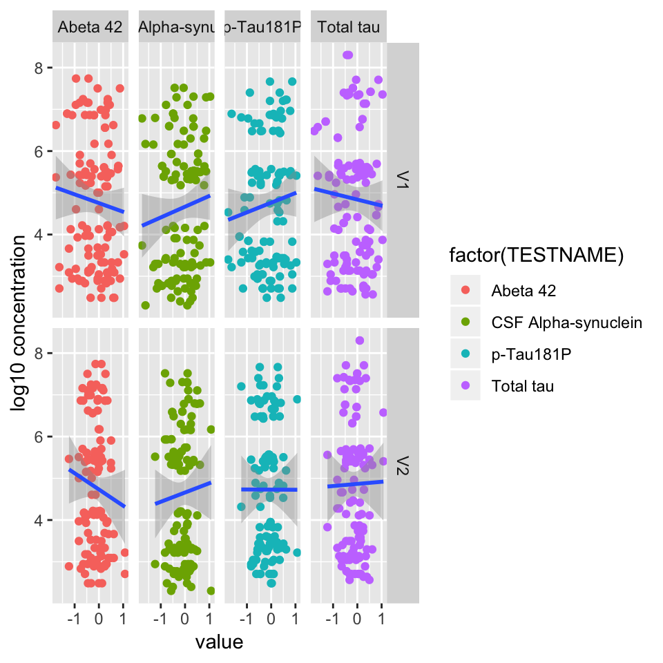

```r
df_axis<-data.frame(S[,c(1,2)])
df_axis$PATNO<-row.names(Y)
df_axis_bio_marker<-merge(df_axis,bio_marker_f[,c(1,6,7)],by=c("PATNO"))
colnames(df_axis_bio_marker)[2]<-"V1"
colnames(df_axis_bio_marker)[3]<-"V2"
df_axis_bio_marker_s<-melt(df_axis_bio_marker,id=c("PATNO","TESTNAME","TESTVALUE"))
colnames(df_axis_bio_marker_s)[4]<-"Axis"
ggplot(df_axis_bio_marker_s, aes(x=value, y=log( as.numeric(as.character(df_axis_bio_marker_s$TESTVALUE))),10) )+facet_grid(Axis~TESTNAME)+geom_point(aes(colour=factor(TESTNAME)))+ geom_smooth(method='lm',formula=y~x)+ylab("log10 concentration")
```

```r
df_axis_bio_marker$TESTVALUE2<-as.numeric(as.character(df_axis_bio_marker$TESTVALUE))
x<-list_test[1]
cor.test(df_axis_bio_marker$V1[df_axis_bio_marker$TESTNAME==x],log(df_axis_bio_marker$TESTVALUE2[df_axis_bio_marker$TESTNAME==x],10))
```

[output not shown]